# Earthquakes 2000-2016

February 6, 2017

## Uses for the app

This shiny app uses the [earthquake database](https://www.kaggle.com/usgs/earthquake-database) from kaggle.com to show where earthquakes occur. I limited the database to 2000-2016 to help it run a little smoother. The app can be used for the following:

- Look in trends in earthquakes.
- See the lines that quakes occur on.
- Look at when quakes happen in specific places.

## Distribution of earthquakes 2000-2016

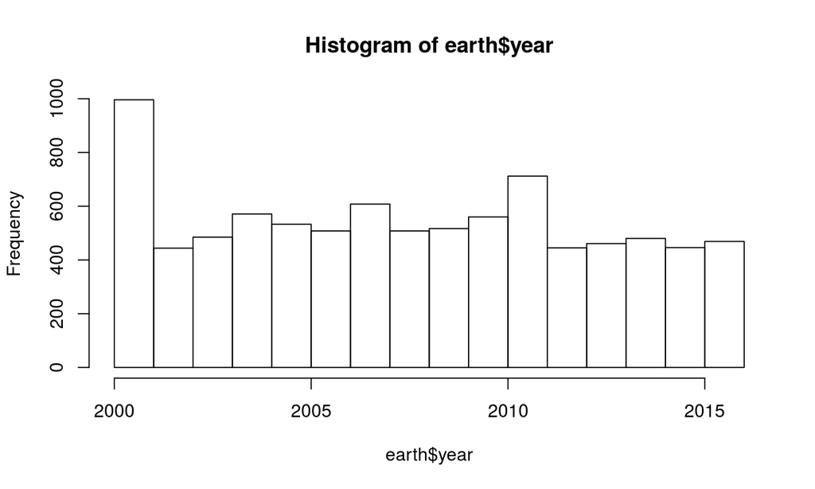

```r
hist(earth$year, breaks = 16)
```

## Goals

The general goal of this app is to make it easy to explore the data by providing a consistant UI to interact with. It is easy to look at hotspots particularly in tearms of where high magnitude earthquakes appear.

The UI has been selected mostly for making those high magnitude earthquakes easy to see. Allowing the user to select the range of magnitudes they want to examine gives them a higher resolution in veiwing the data.

For that purpose the color scale adjusts to match the range of available points, red is always the highest and yellow is always the lowest.

## Future changes

For the most part I am happy with the current state of the app, future versions might include access to more of the earthquakes dataset. I think there is opportunity to investigate the dataset but this app is mostly for the data exploration stage so for that I am very pleased with it. Features I would concider adding:

- Location filter so that it would be posible to focus in on a particular area of the map.
- Some visual indicator of year
- Download output so the user could download a .csv of the markers curently on the map.